# Quality report INS_Inschrijvingen_1CHO_VUdata_cookbook

## INS_Vooropleiding_binnen_HO_sector

| Feature | Result |
| --- | --- |
| Variable type | character |
| Number of missing obs. | 0 (0 %) |
| Number of unique values | 70 |
| Mode | “vooropleiding onbekend” |

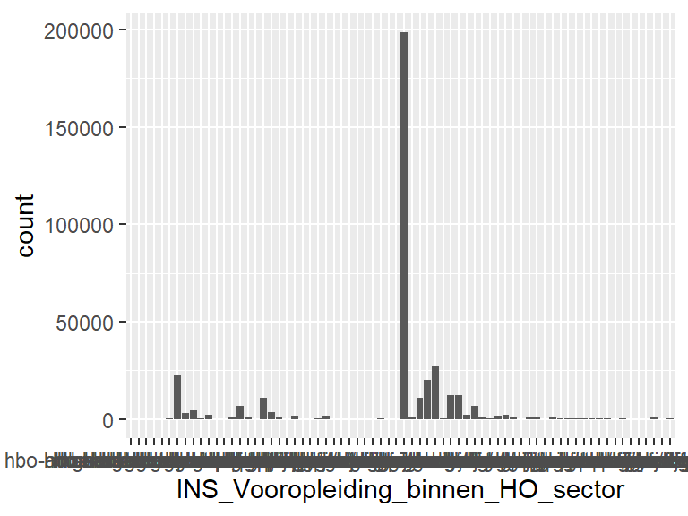

- Observed factor levels: "hbo-ad algemeen", "hbo-ad economie", "hbo-ad gedrag en maatschappij", "hbo-ad taal en cultuur", "hbo-ad techniek", …, "wo-pim gedrag en maatschappij", "wo-pim recht", "wo-vo/ma/bf gezondheidszorg", "wo-vo/ma/bf natuur", "wo-vo/ma/bf onderwijs" (60 values omitted).

## INS_Vooropleiding_voor_HO_profiel

| Feature | Result |
| --- | --- |
| Variable type | character |
| Number of missing obs. | 0 (0 %) |
| Number of unique values | 46 |
| Mode | “vwo profiel natuur/techniek & natuur/gezondheid” |

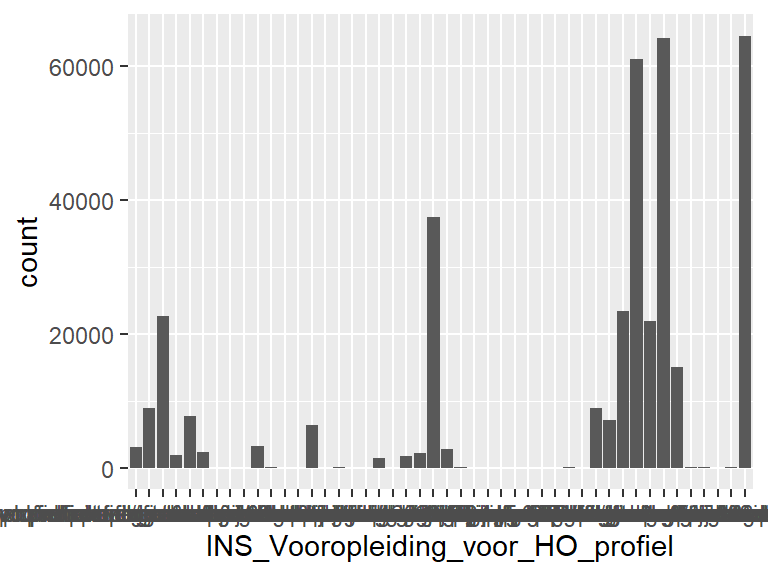

- Observed factor levels: "havo algemeen", "havo profiel cultuur & maatschappij", "havo profiel economie & maatschappij", "havo profiel economie/maatschappij & cultuur/maatschappij", "havo profiel natuur & gezondheid", …, "vwo profiel natuur/gezondheid & cultuur/maatschappij", "vwo profiel natuur/gezondheid & economie/maatschappij", "vwo profiel natuur/techniek & cultuur/maatschappij", "vwo profiel natuur/techniek & economie/maatschappij", "vwo profiel natuur/techniek & natuur/gezondheid" (36 values omitted).

## INS_Vooropleiding_binnen_HO_soort

| Feature | Result |
| --- | --- |
| Variable type | character |
| Number of missing obs. | 0 (0 %) |
| Number of unique values | 70 |
| Mode | “vooropleiding onbekend” |

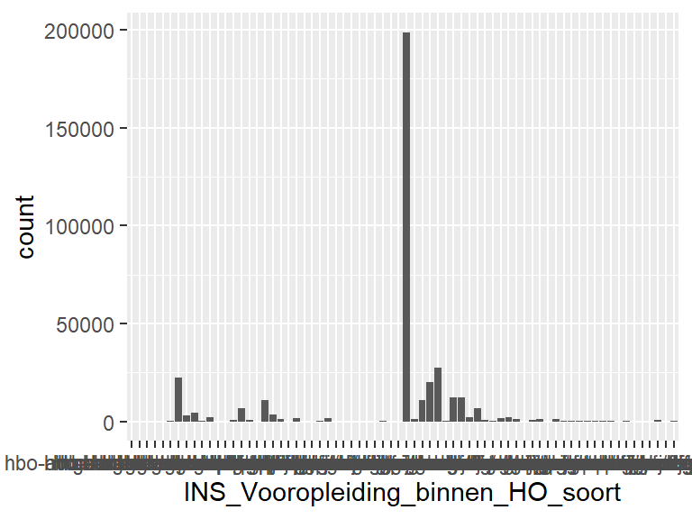

- Observed factor levels: "hbo-ad algemeen", "hbo-ad economie", "hbo-ad gedrag en maatschappij", "hbo-ad taal en cultuur", "hbo-ad techniek", …, "wo-pim gedrag en maatschappij", "wo-pim recht", "wo-vo/ma/bf gezondheidszorg", "wo-vo/ma/bf natuur", "wo-vo/ma/bf onderwijs" (60 values omitted).

## INS_Vooropleiding_voor_HO_soort

| Feature | Result |
| --- | --- |
| Variable type | character |
| Number of missing obs. | 0 (0 %) |
| Number of unique values | 46 |
| Mode | “vwo profiel natuur/techniek & natuur/gezondheid” |

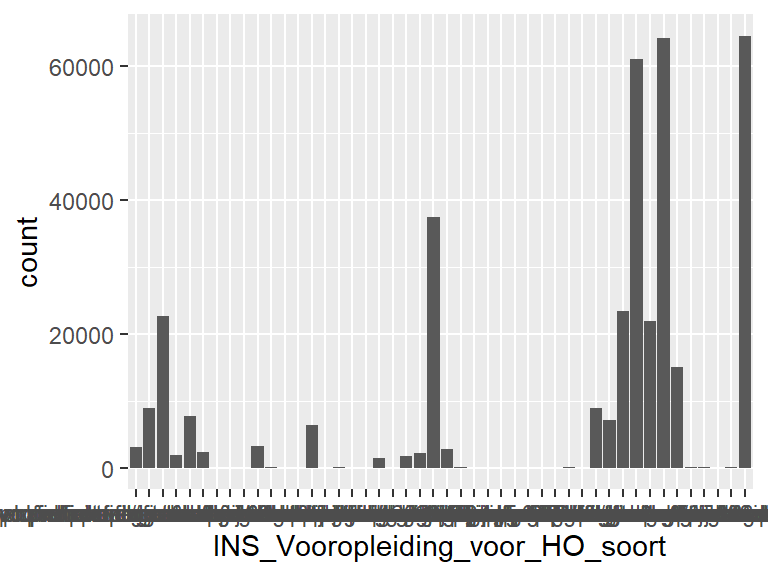

- Observed factor levels: "havo algemeen", "havo profiel cultuur & maatschappij", "havo profiel economie & maatschappij", "havo profiel economie/maatschappij & cultuur/maatschappij", "havo profiel natuur & gezondheid", …, "vwo profiel natuur/gezondheid & cultuur/maatschappij", "vwo profiel natuur/gezondheid & economie/maatschappij", "vwo profiel natuur/techniek & cultuur/maatschappij", "vwo profiel natuur/techniek & economie/maatschappij", "vwo profiel natuur/techniek & natuur/gezondheid" (36 values omitted).

## INS_Hoogste_vooropleiding_soort

| Feature | Result |
| --- | --- |
| Variable type | character |
| Number of missing obs. | 0 (0 %) |
| Number of unique values | 104 |
| Mode | “vwo profiel natuur/techniek & natuur/gezondheid” |

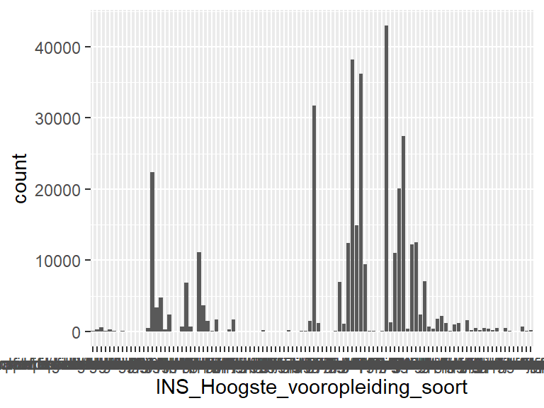

- Observed factor levels: "havo algemeen", "havo profiel cultuur & maatschappij", "havo profiel economie & maatschappij", "havo profiel economie/maatschappij & cultuur/maatschappij", "havo profiel natuur & gezondheid", …, "wo-pim gedrag en maatschappij", "wo-pim recht", "wo-vo/ma/bf gezondheidszorg", "wo-vo/ma/bf natuur", "wo-vo/ma/bf onderwijs" (94 values omitted).

## INS_Hoogste_vooropleiding_cat

| Feature | Result |
| --- | --- |
| Variable type | character |
| Number of missing obs. | 0 (0 %) |
| Number of unique values | 11 |
| Mode | “vwo” |

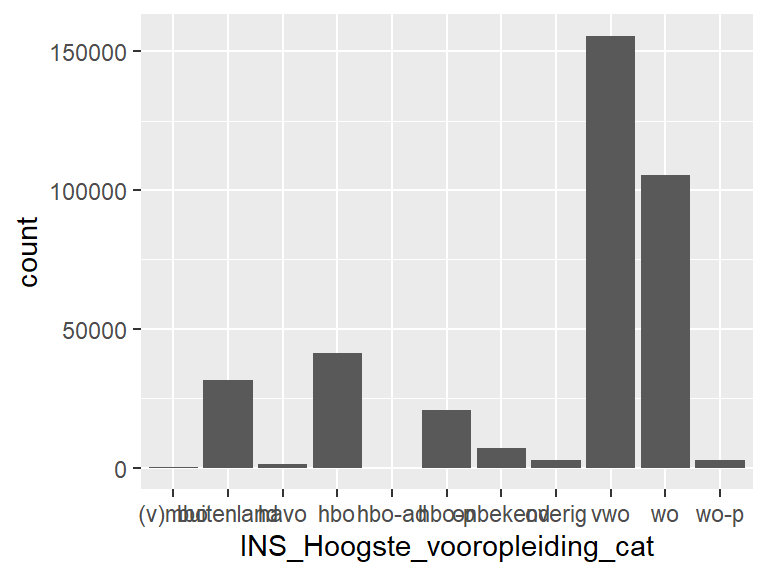

- Observed factor levels: "(v)mbo", "buitenland", "havo", "hbo", "hbo-ad", …, "onbekend", "overig", "vwo", "wo", "wo-p" (1 values omitted).

## INS_Vooropleiding_voor_HO_naam

| Feature | Result |
| --- | --- |
| Variable type | character |
| Number of missing obs. | 60161 (16.3 %) |
| Number of unique values | 635 |
| Mode | “ROC van Amsterdam” |

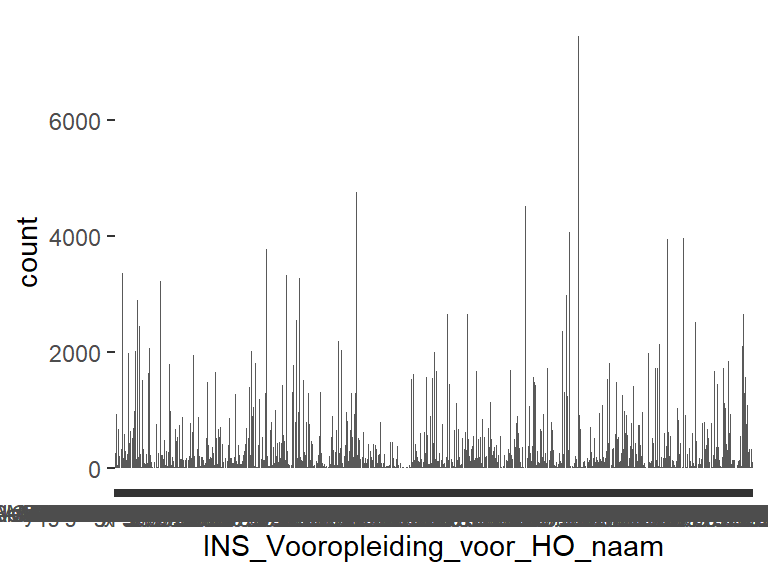

- Observed factor levels: "2College", "Adelbert College", "Aeres (V) MBO", "Agnieten College", "Albeda", …, "Zeldenrust Steelantcollege", "Zernike College", "Zuider Gymnasium", "Zuyderzee Lyceum", "Zwin College SGM" (625 values omitted).

## INS_Vooropleiding_binnen_HO_naam

| Feature | Result |
| --- | --- |
| Variable type | character |
| Number of missing obs. | 202021 (54.73 %) |
| Number of unique values | 139 |
| Mode | “Vrije Universiteit Amsterdam” |

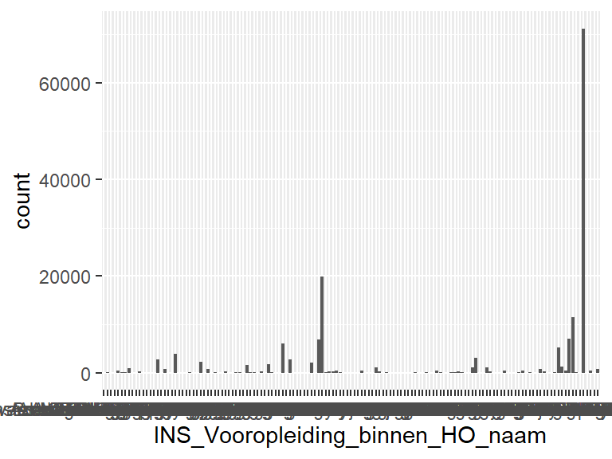

- Observed factor levels: "Academie Artemis", "Aeres Hogeschool", "AG&AI", "Akad v Beeldende Kunst", "Amsterdamse Hogesch vd Kunsten", …, "Vrije Universiteit Amsterdam", "Webster University", "WU", "WUAS", "Zuyd Hogeschool" (129 values omitted).

## INS_Hoogste_vooropleiding_naam

| Feature | Result |
| --- | --- |
| Variable type | character |
| Number of missing obs. | 46809 (12.68 %) |
| Number of unique values | 709 |
| Mode | “Vrije Universiteit Amsterdam” |

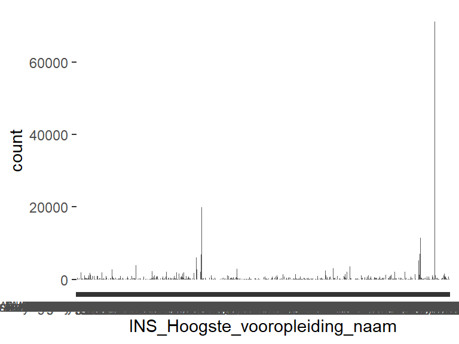

- Observed factor levels: "2College", "Academie Artemis", "Adelbert College", "Aeres Hogeschool", "AG&AI", …, "Zernike College", "Zuider Gymnasium", "Zuyd Hogeschool", "Zuyderzee Lyceum", "Zwin College SGM" (699 values omitted).

## INS_Vooropleiding_voor_HO_postcode

| Feature | Result |
| --- | --- |
| Variable type | numeric |
| Number of missing obs. | 60161 (16.3 %) |
| Number of unique values | 486 |
| Median | 2134 |
| 1st and 3rd quartiles | 1401; 3813 |
| Min. and max. | 1013; 9989 |

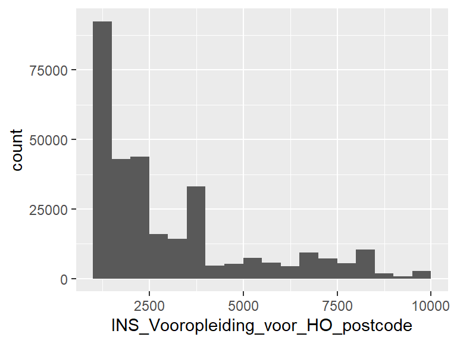

## INS_Vooropleiding_binnen_HO_postcode

| Feature | Result |
| --- | --- |
| Variable type | numeric |
| Number of missing obs. | 202029 (54.73 %) |
| Number of unique values | 100 |
| Median | 1081 |
| 1st and 3rd quartiles | 1081; 3072 |
| Min. and max. | 1011; 9747 |

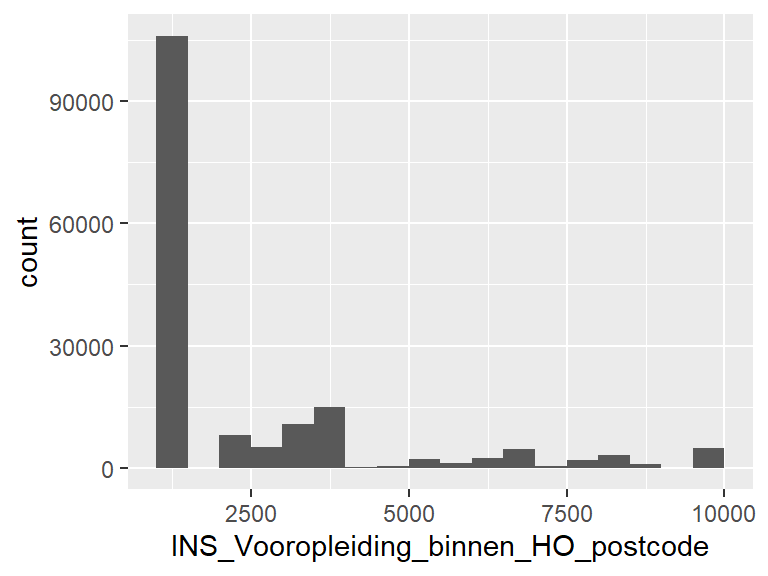

## INS_Hoogste_vooropleiding_postcode

| Feature | Result |
| --- | --- |
| Variable type | numeric |
| Number of missing obs. | 46817 (12.68 %) |
| Number of unique values | 510 |
| Median | 1561 |
| 1st and 3rd quartiles | 1081; 3511 |
| Min. and max. | 1011; 9989 |

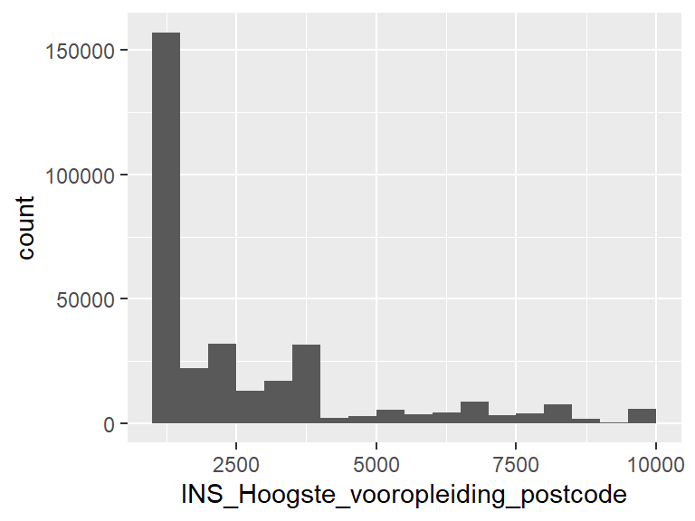

## INS_Vooropleiding_voor_HO_plaats

| Feature | Result |
| --- | --- |
| Variable type | character |
| Number of missing obs. | 60161 (16.3 %) |
| Number of unique values | 230 |
| Mode | “AMSTERDAM” |

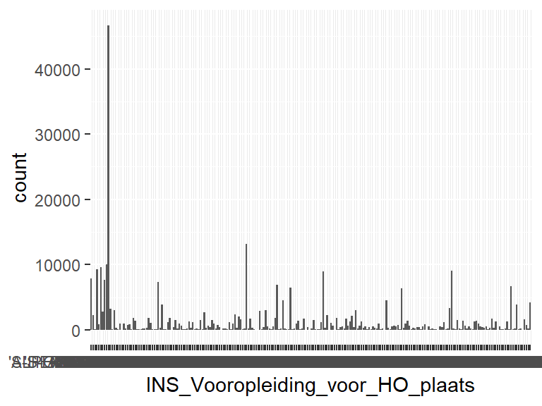

- Observed factor levels: "’S-GRAVENHAGE", "’S-HERTOGENBOSCH", "AALTEN", "ALKMAAR", "ALMELO", …, "ZEVENBERGEN", "ZOETERMEER", "ZUTPHEN", "ZWIJNDRECHT", "ZWOLLE" (220 values omitted).

## INS_Vooropleiding_binnen_HO_plaats

| Feature | Result |
| --- | --- |
| Variable type | character |
| Number of missing obs. | 202021 (54.73 %) |
| Number of unique values | 46 |
| Mode | “AMSTERDAM” |

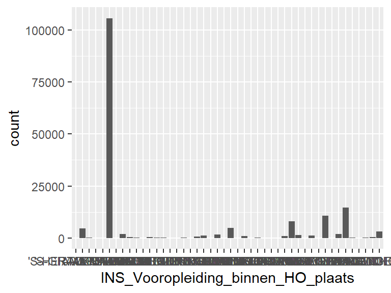

- Observed factor levels: "", "’S-GRAVENHAGE", "’S-HERTOGENBOSCH", "ALKMAAR", "AMERSFOORT", …, "VELP GLD", "VENLO", "VLISSINGEN", "WAGENINGEN", "ZWOLLE" (36 values omitted).

## INS_Hoogste_vooropleiding_plaats

| Feature | Result |
| --- | --- |
| Variable type | character |
| Number of missing obs. | 46809 (12.68 %) |
| Number of unique values | 233 |
| Mode | “AMSTERDAM” |

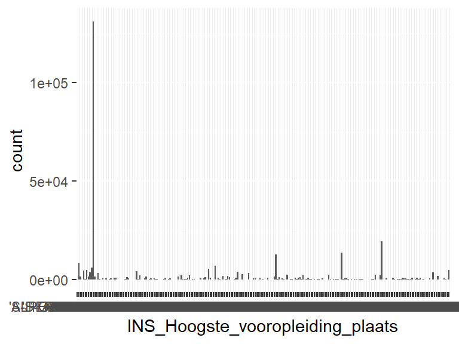

- Observed factor levels: "", "’S-GRAVENHAGE", "’S-HERTOGENBOSCH", "AALTEN", "ALKMAAR", …, "ZEVENBERGEN", "ZOETERMEER", "ZUTPHEN", "ZWIJNDRECHT", "ZWOLLE" (223 values omitted).

## INS_Examenresultaat

| Feature | Result |
| --- | --- |
| Variable type | character |
| Number of missing obs. | 279049 (75.6 %) |
| Number of unique values | 3 |
| Mode | “Examen behaald” |

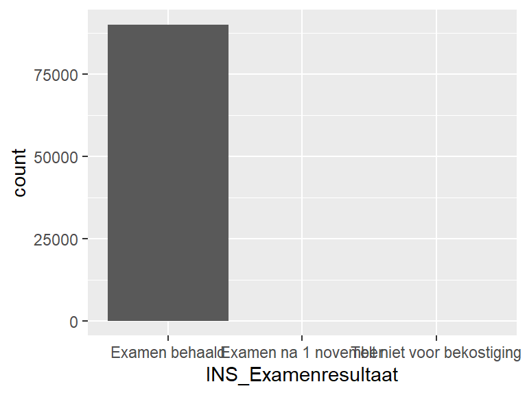

- Observed factor levels: "Examen behaald", "Examen na 1 november", "Telt niet voor bekostiging".

## INS_Hoogste_vooropleiding_soort_cat

- The variable only takes one value: "NA".

## INS_Indicatie_eerste_jaars_instelling_cat

| Feature | Result |
| --- | --- |
| Variable type | character |
| Number of missing obs. | 0 (0 %) |
| Number of unique values | 3 |
| Mode | “Ouderejaars VU” |

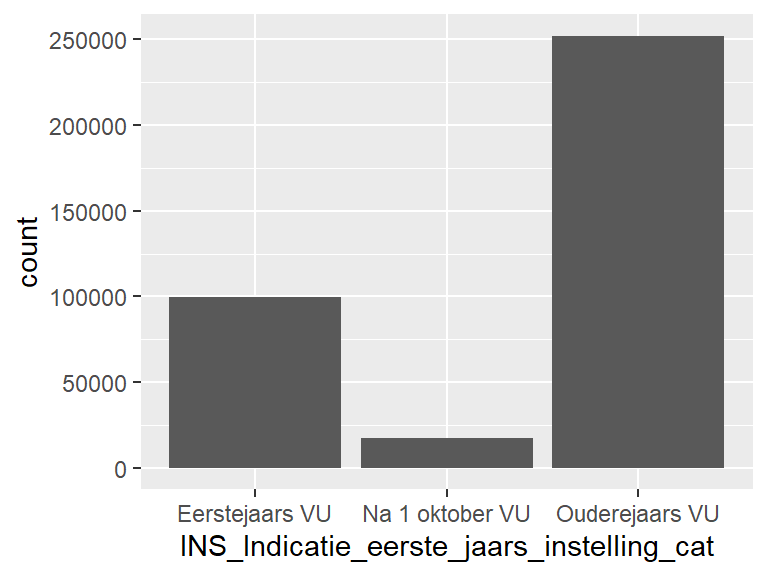

- Observed factor levels: "Eerstejaars VU", "Na 1 oktober VU", "Ouderejaars VU".

## INS_Indicatie_eerste_jaars_instelling_naam

| Feature | Result |
| --- | --- |
| Variable type | character |
| Number of missing obs. | 0 (0 %) |
| Number of unique values | 5 |
| Mode | “Hoofd - Ouderejaars VU” |

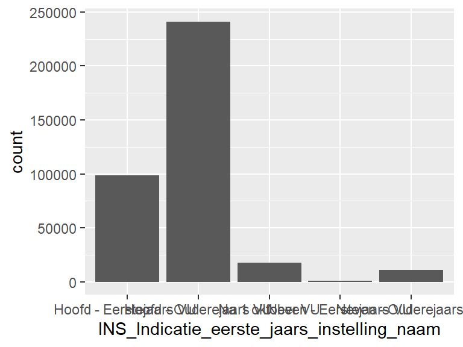

- Observed factor levels: "Hoofd - Eerstejaars VU ", "Hoofd - Ouderejaars VU", "Na 1 oktober VU", "Neven - Eerstejaars VU", "Neven - Ouderejaars VU".

## INS_Indicatie_eerste_jaars_opleiding_en_instelling_naam

| Feature | Result |
| --- | --- |
| Variable type | character |
| Number of missing obs. | 0 (0 %) |
| Number of unique values | 3 |
| Mode | “Ouderejaars opleiding” |

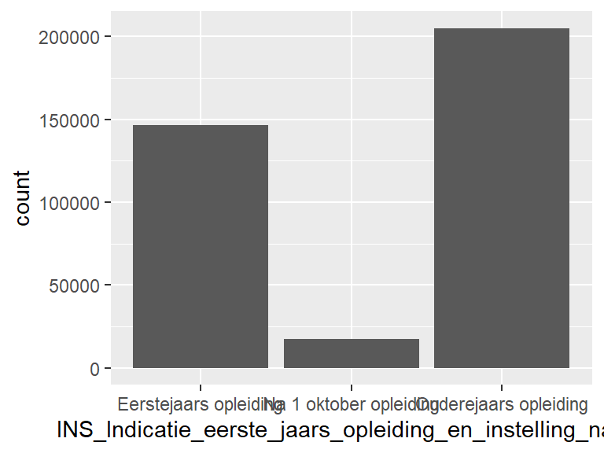

- Observed factor levels: "Eerstejaars opleiding", "Na 1 oktober opleiding", "Ouderejaars opleiding".

## DEM_Nationaliteit_1_naam

| Feature | Result |
| --- | --- |
| Variable type | character |
| Number of missing obs. | 0 (0 %) |
| Number of unique values | 150 |
| Mode | “Nederlandse” |

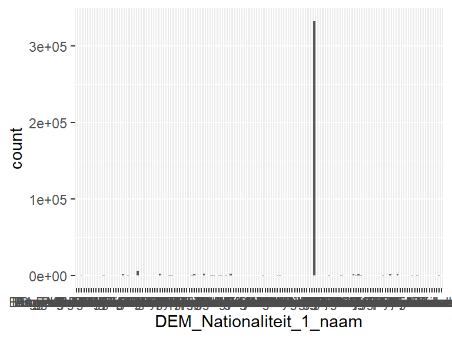

- Observed factor levels: "Afghaanse", "Albanese", "Amerikaans burger", "Amerikaans onderdaan", "Argentijnse", …, "Zuid-Afrikaanse", "Zuid-Koreaanse", "Zuid-Soedanese", "Zweedse", "Zwitserse" (140 values omitted).

## DEM_Nationaliteit_2_naam

| Feature | Result |
| --- | --- |
| Variable type | character |
| Number of missing obs. | 0 (0 %) |
| Number of unique values | 160 |
| Mode | “NULL” |

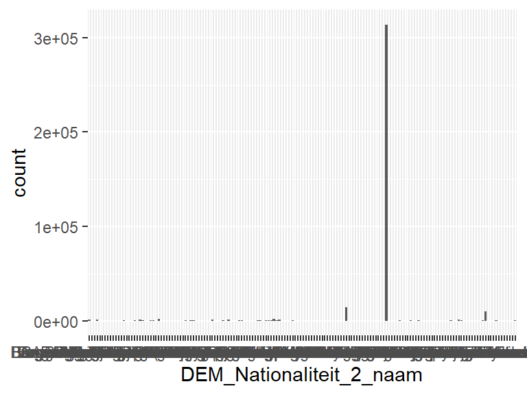

- Observed factor levels: "Afghaanse", "Albanese", "Algerijnse", "Amerikaans burger", "Amerikaans onderdaan", …, "Zimbabwaanse", "Zuid-Afrikaanse", "Zuid-Koreaanse", "Zweedse", "Zwitserse" (150 values omitted).

## DEM_Nationaliteit_3_naam

| Feature | Result |
| --- | --- |
| Variable type | character |
| Number of missing obs. | 0 (0 %) |
| Number of unique values | 60 |
| Mode | “NULL” |

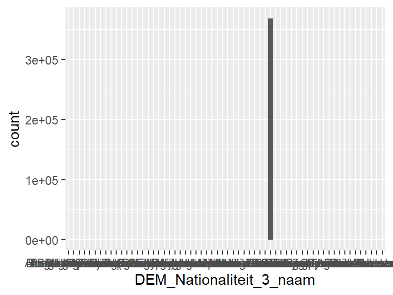

- Observed factor levels: "Albanese", "Algerijnse", "Amerikaans burger", "Amerikaans onderdaan", "Argentijnse", …, "Vietnamese", "Zuid-Afrikaanse", "Zuid-Koreaanse", "Zweedse", "Zwitserse" (50 values omitted).

## DEM_Leeftijd_peildatum_1_jan_cat

| Feature | Result |
| --- | --- |
| Variable type | factor |
| Number of missing obs. | 0 (0 %) |
| Number of unique values | 7 |
| Mode | “25 en ouder” |
| Reference category | Onder 18 |

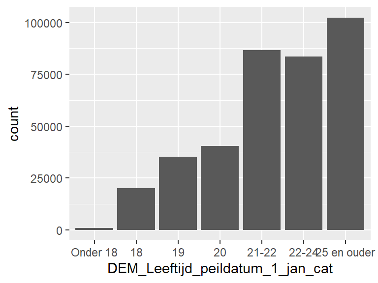

- Observed factor levels: "18", "19", "20", "21-22", "22-24", "25 en ouder", "Onder 18".

## INS_Soort_inschrijving_1CHO

| Feature | Result |
| --- | --- |
| Variable type | character |
| Number of missing obs. | 0 (0 %) |
| Number of unique values | 4 |
| Mode | “Hoofdinschrijving” |

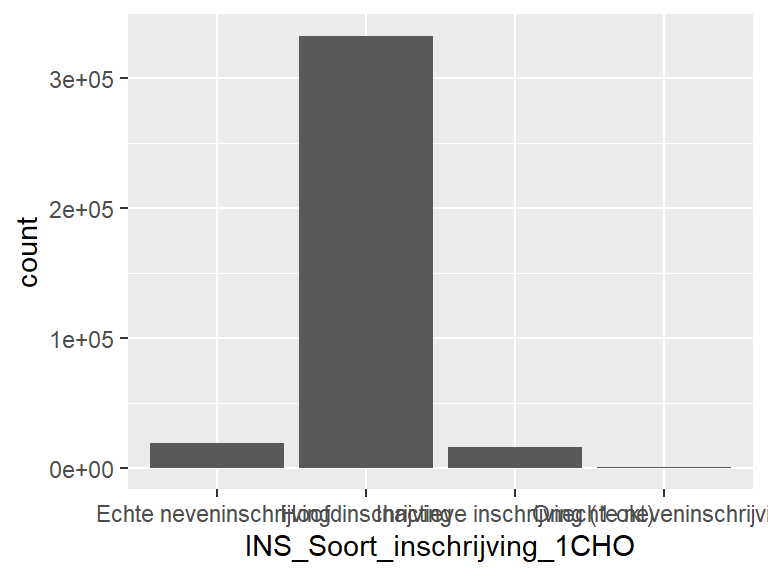

- Observed factor levels: "Echte neveninschrijving ", "Hoofdinschrijving", "Inactieve inschrijving (1 okt)", "Onechte neveninschrijving".

## INS_Vooropleiding_binnen_HO_Instellingsnaam

| Feature | Result |
| --- | --- |
| Variable type | character |
| Number of missing obs. | 202021 (54.73 %) |
| Number of unique values | 139 |
| Mode | “Vrije Universiteit Amsterdam” |

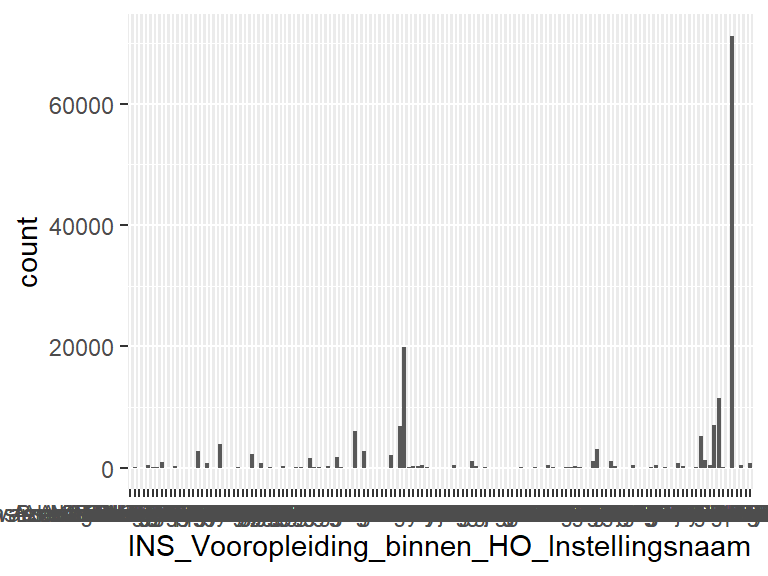

- Observed factor levels: "Academie Artemis", "Aeres Hogeschool", "AG&AI", "Akad v Beeldende Kunst", "Amsterdamse Hogesch vd Kunsten", …, "Vrije Universiteit Amsterdam", "Webster University", "WU", "WUAS", "Zuyd Hogeschool" (129 values omitted).

## INS_Vooropleiding_voor_HO_Instellingsnaam

| Feature | Result |
| --- | --- |
| Variable type | character |
| Number of missing obs. | 60161 (16.3 %) |
| Number of unique values | 635 |
| Mode | “ROC van Amsterdam” |

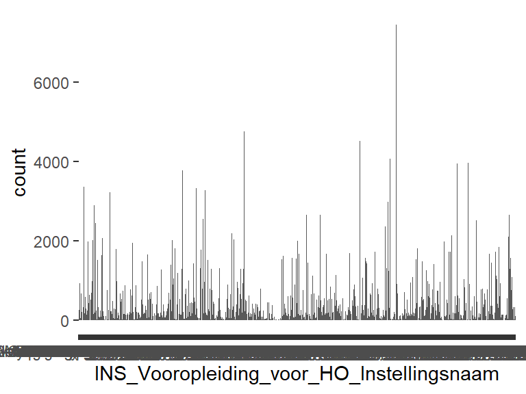

- Observed factor levels: "2College", "Adelbert College", "Aeres (V) MBO", "Agnieten College", "Albeda", …, "Zeldenrust Steelantcollege", "Zernike College", "Zuider Gymnasium", "Zuyderzee Lyceum", "Zwin College SGM" (625 values omitted).

## INS_Verblijfsjaren_wetenschappelijk_onderwijs_cat

| Feature | Result |
| --- | --- |
| Variable type | factor |
| Number of missing obs. | 16147 (4.37 %) |
| Number of unique values | 6 |
| Mode | “>6” |
| Reference category | 0 |

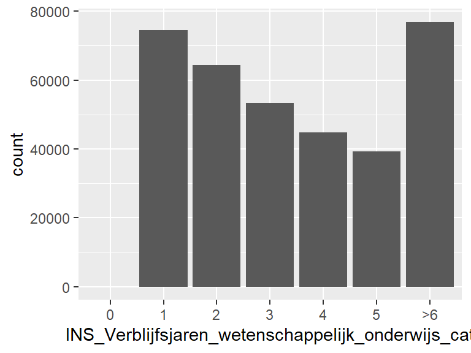

- Observed factor levels: ">6", "0", "1", "2", "3", "4", "5".